# Practica 1

```python
import Clasificador
import EstrategiaParticionado
import Datos
from sklearn import preprocessing
from sklearn.model_selection import cross_val_score
from sklearn.naive_bayes import GaussianNB
from sklearn.naive_bayes import MultinomialNB
from sklearn.model_selection import train_test_split
from sklearn.metrics import accuracy_score, confusion_matrix
from sklearn.model_selection import train_test_split, cross_val_score, KFold, cross_val_predict
import sklearn.naive_bayes as nb
import numpy as np
from astropy.table import Table
from sklearn import metrics
import scikitplot as skplt
from sklearn.metrics import roc_curve
from sklearn.metrics import roc_auc_score
from matplotlib import pyplot
```

## Apartado 1: Particionado

### Validación Simple tic-tac-toe.data

Probamos la validación simple con una proporción de 0.7 que corresponde a los datos de entrenamiento y el resto (0.3) a los datos de prueba. Realizamos una sola ejecución para disminuir los datos de salida.

```python
dataset = Datos.Datos('ConjuntoDatos/tic-tac-toe.data')
validacionSimple = EstrategiaParticionado.ValidacionSimple(0.7, 1)
particiones = validacionSimple.creaParticiones(dataset.datos)
for particion in particiones:
    print("Indices Entrenamiento:", particion.indicesTrain)
    print("\n")
    print("Indices Prueba:", particion.indicesTest)
```

```
Indices Entrenamiento: [241, 242, 243, 244, 245, 246, 247, 248, 249, 250, 251, 252, 253, 254, 255, 256, 257, 258, 259, 260, 261, 262, 263, 264, 265, 266, 267, 268, 269, 270, 271, 272, 273, 274, 275, 276, 277, 278, 279, 280, 281, 282, 283, 284, 285, 286, 287, 288, 289, 290, 291, 292, 293, 294, 295, 2…


Indices Prueba: [911, 912, 913, 914, 915, 916, 917, 918, 919, 920, 921, 922, 923, 924, 925, 926, 927, 928, 929, 930, 931, 932, 933, 934, 935, 936, 937, 938, 939, 940, 941, 942, 943, 944, 945, 946, 947, 948, 949, 950, 951, 952, 953, 954, 955, 956, 957, 0, 1, 2, 3, 4, 5, 6, 7, 8, 9, 10, 11, 12, 13, 14…
```

### Validación Cruzada tic-tac-toe.data

```python
dataset = Datos.Datos('ConjuntoDatos/tic-tac-toe.data')
validacionCruzada = EstrategiaParticionado.ValidacionCruzada(10)
particiones = validacionCruzada.creaParticiones(dataset.datos)
for particion in particiones:
    print("Indices Entrenamiento:", particion.indicesTrain)
    print("\n")
    print("Indices Prueba:", particion.indicesTest)
    print("\n")
```

```
Indices Entrenamiento: [95, 96, 97, 98, 99, 100, 101, 102, 103, 104, 105, 106, 107, 108, 109, 110, 111, 112, 113, 114, 115, 116, 117, 118, 119, 120, 121, 122, 123, 124, 125, 126, 127, 128, 129, 130, 131, 132, 133, 134, 135, 136, 137, 138, 139, 140, 141, 142, 143, 144, 145, 146, 147, 148, 149, 150, 1…


Indices Prueba: [0, 1, 2, 3, 4, 5, 6, 7, 8, 9, 10, 11, 12, 13, 14, 15, 16, 17, 18, 19, 20, 21, 22, 23, 24, 25, 26, 27, 28, 29, 30, 31, 32, 33, 34, 35, 36, 37, 38, 39, 40, 41, 42, 43, 44, 45, 46, 47, 48, 49, 50, 51, 52, 53, 54, 55, 56, 57, 58, 59, 60, 61, 62, 63, 64, 65, 66, 67, 68, 69, 70, 71, 72, 7…


Indices Entrenamiento: [0, 1, 2, 3, 4, 5, 6, 7, 8, 9, 10, 11, 12, 13, 14, 15, 16, 17, 18, 19, 20, 21, 22, 23, 24, 25, 26, 27, 28, 29, 30, 31, 32, 33, 34, 35, 36, 37, 38, 39, 40, 41, 42, 43, 44, 45, 46, 47, 48, 49, 50, 51, 52, 53, 54, 55, 56, 57, 58, 59, 60, 61, 62, 63, 64, 65, 66, 67, 68, 69, 70, 71…


Indices Prueba: [95, 96, 97, 98, 99, 100, 101, 102, 103, 104, 105, 106, 107, 108, 109, 110, 111, 112, 113, 114, 115, 116, 117, 118, 119, 120, 121, 122, 123, 124, 125, 126, 127, 128, 129, 130, 131, 132, 133, 134, 135, 136, 137, 138, 139, 140, 141, 142, 143, 144, 145, 146, 147, 148, 149, 150, 151, 152…


Indices Entrenamiento: [0, 1, 2, 3, 4, 5, 6, 7, 8, 9, 10, 11, 12, 13, 14, 15, 16, 17, 18, 19, 20, 21, 22, 23, 24, 25, 26, 27, 28, 29, 30, 31, 32, 33, 34, 35, 36, 37, 38, 39, 40, 41, 42, 43, 44, 45, 46, 47, 48, 49, 50, 51, 52, 53, 54, 55, 56, 57, 58, 59, 60, 61, 62, 63, 64, 65, 66, 67, 68, 69, 70, 71…


Indices Prueba: [190, 191, 192, 193, 194, 195, 196, 197, 198, 199, 200, 201, 202, 203, 204, 205, 206, 207, 208, 209, 210, 211, 212, 213, 214, 215, 216, 217, 218, 219, 220, 221, 222, 223, 224, 225, 226, 227, 228, 229, 230, 231, 232, 233, 234, 235, 236, 237, 238, 239, 240, 241, 242, 243, 244, 245, 246…


Indices Entrenamiento: [0, 1, 2, 3, 4, 5, 6, 7, 8, 9, 10, 11, 12, 13, 14, 15, 16, 17, 18, 19, 20, 21, 22, 23, 24, 25, 26, 27, 28, 29, 30, 31, 32, 33, 34, 35, 36, 37, 38, 39, 40, 41, 42, 43, 44, 45, 46, 47, 48, 49, 50, 51, 52, 53, 54, 55, 56, 57, 58, 59, 60, 61, 62, 63, 64, 65, 66, 67, 68, 69, 70, 71…


Indices Prueba: [285, 286, 287, 288, 289, 290, 291, 292, 293, 294, 295, 296, 297, 298, 299, 300, 301, 302, 303, 304, 305, 306, 307, 308, 309, 310, 311, 312, 313, 314, 315, 316, 317, 318, 319, 320, 321, 322, 323, 324, 325, 326, 327, 328, 329, 330, 331, 332, 333, 334, 335, 336, 337, 338, 339, 340, 341…


Indices Entrenamiento: [0, 1, 2, 3, 4, 5, 6, 7, 8, 9, 10, 11, 12, 13, 14, 15, 16, 17, 18, 19, 20, 21, 22, 23, 24, 25, 26, 27, 28, 29, 30, 31, 32, 33, 34, 35, 36, 37, 38, 39, 40, 41, 42, 43, 44, 45, 46, 47, 48, 49, 50, 51, 52, 53, 54, 55, 56, 57, 58, 59, 60, 61, 62, 63, 64, 65, 66, 67, 68, 69, 70, 71…


Indices Prueba: [380, 381, 382, 383, 384, 385, 386, 387, 388, 389, 390, 391, 392, 393, 394, 395, 396, 397, 398, 399, 400, 401, 402, 403, 404, 405, 406, 407, 408, 409, 410, 411, 412, 413, 414, 415, 416, 417, 418, 419, 420, 421, 422, 423, 424, 425, 426, 427, 428, 429, 430, 431, 432, 433, 434, 435, 436…


Indices Entrenamiento: [0, 1, 2, 3, 4, 5, 6, 7, 8, 9, 10, 11, 12, 13, 14, 15, 16, 17, 18, 19, 20, 21, 22, 23, 24, 25, 26, 27, 28, 29, 30, 31, 32, 33, 34, 35, 36, 37, 38, 39, 40, 41, 42, 43, 44, 45, 46, 47, 48, 49, 50, 51, 52, 53, 54, 55, 56, 57, 58, 59, 60, 61, 62, 63, 64, 65, 66, 67, 68, 69, 70, 71…


Indices Prueba: [475, 476, 477, 478, 479, 480, 481, 482, 483, 484, 485, 486, 487, 488, 489, 490, 491, 492, 493, 494, 495, 496, 497, 498, 499, 500, 501, 502, 503, 504, 505, 506, 507, 508, 509, 510, 511, 512, 513, 514, 515, 516, 517, 518, 519, 520, 521, 522, 523, 524, 525, 526, 527, 528, 529, 530, 531…


Indices Entrenamiento: [0, 1, 2, 3, 4, 5, 6, 7, 8, 9, 10, 11, 12, 13, 14, 15, 16, 17, 18, 19, 20, 21, 22, 23, 24, 25, 26, 27, 28, 29, 30, 31, 32, 33, 34, 35, 36, 37, 38, 39, 40, 41, 42, 43, 44, 45, 46, 47, 48, 49, 50, 51, 52, 53, 54, 55, 56, 57, 58, 59, 60, 61, 62, 63, 64, 65, 66, 67, 68, 69, 70, 71…

```

[output cut: 20 more lines]

### Validación Simple german.data

Probamos la validación simple con una proporción de 0.5 que corresponde a los datos de entrenamiento y el resto (0.5) a los datos de prueba. Realizamos una sola ejecución para disminuir los datos de salida.

```python
dataset = Datos.Datos('ConjuntoDatos/german.data')
validacionSimple = EstrategiaParticionado.ValidacionSimple(0.5, 1)
particiones = validacionSimple.creaParticiones(dataset.datos)
for particion in particiones:
    print("Indices Entrenamiento:", particion.indicesTrain)
    print("\n")
    print("Indices Prueba:", particion.indicesTest)
```

```
Indices Entrenamiento: [691, 692, 693, 694, 695, 696, 697, 698, 699, 700, 701, 702, 703, 704, 705, 706, 707, 708, 709, 710, 711, 712, 713, 714, 715, 716, 717, 718, 719, 720, 721, 722, 723, 724, 725, 726, 727, 728, 729, 730, 731, 732, 733, 734, 735, 736, 737, 738, 739, 740, 741, 742, 743, 744, 745, 7…


Indices Prueba: [191, 192, 193, 194, 195, 196, 197, 198, 199, 200, 201, 202, 203, 204, 205, 206, 207, 208, 209, 210, 211, 212, 213, 214, 215, 216, 217, 218, 219, 220, 221, 222, 223, 224, 225, 226, 227, 228, 229, 230, 231, 232, 233, 234, 235, 236, 237, 238, 239, 240, 241, 242, 243, 244, 245, 246, 247…
```

### Validación Cruzada german.data

```python
dataset = Datos.Datos('ConjuntoDatos/german.data')
validacionCruzada = EstrategiaParticionado.ValidacionCruzada(4)
particiones = validacionCruzada.creaParticiones(dataset.datos)
for particion in particiones:
    print("Indices Entrenamiento:", particion.indicesTrain)
    print("\n")
    print("Indices Prueba:", particion.indicesTest)
    print("\n")
```

```
Indices Entrenamiento: [250, 251, 252, 253, 254, 255, 256, 257, 258, 259, 260, 261, 262, 263, 264, 265, 266, 267, 268, 269, 270, 271, 272, 273, 274, 275, 276, 277, 278, 279, 280, 281, 282, 283, 284, 285, 286, 287, 288, 289, 290, 291, 292, 293, 294, 295, 296, 297, 298, 299, 300, 301, 302, 303, 304, 3…


Indices Prueba: [0, 1, 2, 3, 4, 5, 6, 7, 8, 9, 10, 11, 12, 13, 14, 15, 16, 17, 18, 19, 20, 21, 22, 23, 24, 25, 26, 27, 28, 29, 30, 31, 32, 33, 34, 35, 36, 37, 38, 39, 40, 41, 42, 43, 44, 45, 46, 47, 48, 49, 50, 51, 52, 53, 54, 55, 56, 57, 58, 59, 60, 61, 62, 63, 64, 65, 66, 67, 68, 69, 70, 71, 72, 7…


Indices Entrenamiento: [0, 1, 2, 3, 4, 5, 6, 7, 8, 9, 10, 11, 12, 13, 14, 15, 16, 17, 18, 19, 20, 21, 22, 23, 24, 25, 26, 27, 28, 29, 30, 31, 32, 33, 34, 35, 36, 37, 38, 39, 40, 41, 42, 43, 44, 45, 46, 47, 48, 49, 50, 51, 52, 53, 54, 55, 56, 57, 58, 59, 60, 61, 62, 63, 64, 65, 66, 67, 68, 69, 70, 71…


Indices Prueba: [250, 251, 252, 253, 254, 255, 256, 257, 258, 259, 260, 261, 262, 263, 264, 265, 266, 267, 268, 269, 270, 271, 272, 273, 274, 275, 276, 277, 278, 279, 280, 281, 282, 283, 284, 285, 286, 287, 288, 289, 290, 291, 292, 293, 294, 295, 296, 297, 298, 299, 300, 301, 302, 303, 304, 305, 306…


Indices Entrenamiento: [0, 1, 2, 3, 4, 5, 6, 7, 8, 9, 10, 11, 12, 13, 14, 15, 16, 17, 18, 19, 20, 21, 22, 23, 24, 25, 26, 27, 28, 29, 30, 31, 32, 33, 34, 35, 36, 37, 38, 39, 40, 41, 42, 43, 44, 45, 46, 47, 48, 49, 50, 51, 52, 53, 54, 55, 56, 57, 58, 59, 60, 61, 62, 63, 64, 65, 66, 67, 68, 69, 70, 71…


Indices Prueba: [500, 501, 502, 503, 504, 505, 506, 507, 508, 509, 510, 511, 512, 513, 514, 515, 516, 517, 518, 519, 520, 521, 522, 523, 524, 525, 526, 527, 528, 529, 530, 531, 532, 533, 534, 535, 536, 537, 538, 539, 540, 541, 542, 543, 544, 545, 546, 547, 548, 549, 550, 551, 552, 553, 554, 555, 556…


Indices Entrenamiento: [0, 1, 2, 3, 4, 5, 6, 7, 8, 9, 10, 11, 12, 13, 14, 15, 16, 17, 18, 19, 20, 21, 22, 23, 24, 25, 26, 27, 28, 29, 30, 31, 32, 33, 34, 35, 36, 37, 38, 39, 40, 41, 42, 43, 44, 45, 46, 47, 48, 49, 50, 51, 52, 53, 54, 55, 56, 57, 58, 59, 60, 61, 62, 63, 64, 65, 66, 67, 68, 69, 70, 71…


Indices Prueba: [750, 751, 752, 753, 754, 755, 756, 757, 758, 759, 760, 761, 762, 763, 764, 765, 766, 767, 768, 769, 770, 771, 772, 773, 774, 775, 776, 777, 778, 779, 780, 781, 782, 783, 784, 785, 786, 787, 788, 789, 790, 791, 792, 793, 794, 795, 796, 797, 798, 799, 800, 801, 802, 803, 804, 805, 806…
```

### Análisis, Ventajas y Desventajas

La validación simple es la más sencilla y menos costosa de implementar. Sin embargo, la cruzada es más robusta ya que ayuda a mezclar los datos y no sesgar de una manera tan evidente como la validación simple.

## Apartado 2: Naive Bayes

Ahora calcularemos el porcentaje de error y su desviación típica para los dos ficheros de datos y con los distintos métodos de particionamiento. También tendremos en cuenta la corrección de Laplace.

### Naive Bayes con Validación Simple (tic-tac-toe.data)

```python
clasificador = Clasificador.ClasificadorNaiveBayes(laplace = 1)
dataset = Datos.Datos('ConjuntoDatos/tic-tac-toe.data')
validacionSimple = EstrategiaParticionado.ValidacionSimple(0.6, 5)
particiones = validacionSimple.creaParticiones(dataset.datos)
media_errores, std_errores = clasificador.validacion(validacionSimple, dataset, clasificador, seed=None)
print("Media de errores con correción de Laplace:", media_errores)
print("Desviación típica de errores con correción de Laplace:", std_errores)
meanVSTL = media_errores
devVSTL = std_errores
```

```
Media de errores con correción de Laplace: 0.8218181818181819
Desviación típica de errores con correción de Laplace: 0.07642898520229165
```

```python
clasificador = Clasificador.ClasificadorNaiveBayes(laplace = 0)
dataset = Datos.Datos('ConjuntoDatos/tic-tac-toe.data')
validacionSimple = EstrategiaParticionado.ValidacionSimple(0.6, 5)
particiones = validacionSimple.creaParticiones(dataset.datos)
media_errores, std_errores = clasificador.validacion(validacionSimple, dataset, clasificador, seed=None)
print("Media de errores sin correción de Laplace:", media_errores)
print("Desviación típica de errores sin correción de Laplace:", std_errores)
meanVST = media_errores
devVST = std_errores
```

```
Media de errores sin correción de Laplace: 0.8670129870129871
Desviación típica de errores sin correción de Laplace: 0.0756981337608978
```

### Naibe Bayes con Validación Cruzada (tic-tac-toe.data)

```python
clasificador = Clasificador.ClasificadorNaiveBayes(laplace = 1)
dataset = Datos.Datos('ConjuntoDatos/tic-tac-toe.data')
validacionCruzada = EstrategiaParticionado.ValidacionCruzada(30)
particiones = validacionCruzada.creaParticiones(dataset.datos)
media_errores, std_errores = clasificador.validacion(validacionCruzada, dataset, clasificador, seed=None)
print("Media de errores con correción de Laplace:", media_errores)
print("Desviación típica de errores con correción de Laplace:", std_errores)
meanVCTL = media_errores
devVCTL = std_errores
```

```
Media de errores con correción de Laplace: 0.3743951612903226
Desviación típica de errores con correción de Laplace: 0.25754376116197847
```

```python
clasificador = Clasificador.ClasificadorNaiveBayes(laplace = 0)
dataset = Datos.Datos('ConjuntoDatos/tic-tac-toe.data')
validacionCruzada = EstrategiaParticionado.ValidacionCruzada(30)
particiones = validacionCruzada.creaParticiones(dataset.datos)
media_errores, std_errores = clasificador.validacion(validacionCruzada, dataset, clasificador, seed=None)
print("Media de errores sin correción de Laplace:", media_errores)
print("Desviación típica de errores sin correción de Laplace:", std_errores)
meanVCT = media_errores
devVCT = std_errores
```

```
Media de errores sin correción de Laplace: 0.3743951612903226
Desviación típica de errores sin correción de Laplace: 0.25754376116197847
```

### Naive Bayes con Validación Simple (german.data)

```python
clasificador = Clasificador.ClasificadorNaiveBayes(laplace = 1)
dataset = Datos.Datos('ConjuntoDatos/german.data')
validacionSimple = EstrategiaParticionado.ValidacionSimple(0.6, 5)
particiones = validacionSimple.creaParticiones(dataset.datos)
media_errores, std_errores = clasificador.validacion(validacionSimple, dataset, clasificador, seed=None)
print("Media de errores con correción de Laplace:", media_errores)
print("Desviación típica de errores con correción de Laplace:", std_errores)
meanVSGL = media_errores
devVSGL = std_errores
```

```
Media de errores con correción de Laplace: 0.26982543640897755
Desviación típica de errores con correción de Laplace: 0.005553879663670866
```

```python
clasificador = Clasificador.ClasificadorNaiveBayes(laplace = 0)
dataset = Datos.Datos('ConjuntoDatos/german.data')
validacionSimple = EstrategiaParticionado.ValidacionSimple(0.6, 5)
particiones = validacionSimple.creaParticiones(dataset.datos)
media_errores, std_errores = clasificador.validacion(validacionSimple, dataset, clasificador, seed=None)
print("Media de errores sin correción de Laplace:", media_errores)
print("Desviación típica de errores sin correción de Laplace:", std_errores)
meanVSG = media_errores
devVSG = std_errores
```

```
Media de errores sin correción de Laplace: 0.28778054862842894
Desviación típica de errores sin correción de Laplace: 0.01605334358047989
```

### Naive Bayes con Validación Cruzada (german.data)

```python
clasificador = Clasificador.ClasificadorNaiveBayes(laplace = 1)
dataset = Datos.Datos('ConjuntoDatos/german.data')
validacionCruzada = EstrategiaParticionado.ValidacionCruzada(3)
particiones = validacionCruzada.creaParticiones(dataset.datos)
media_errores, std_errores = clasificador.validacion(validacionCruzada, dataset, clasificador, seed=None)
print("Media de errores con correción de Laplace:", media_errores)
print("Desviación típica de errores con correción de Laplace:", std_errores)
meanVCGL = media_errores
devVCGL = std_errores
```

```
Media de errores con correción de Laplace: 0.2739895584206961
Desviación típica de errores con correción de Laplace: 0.008248656238043325
```

```python
clasificador = Clasificador.ClasificadorNaiveBayes(laplace = 0)
dataset = Datos.Datos('ConjuntoDatos/german.data')
validacionCruzada = EstrategiaParticionado.ValidacionCruzada(3)
particiones = validacionCruzada.creaParticiones(dataset.datos)
media_errores, std_errores = clasificador.validacion(validacionCruzada, dataset, clasificador, seed=None)
print("Media de errores sin correción de Laplace:", media_errores)
print("Desviación típica de errores sin correción de Laplace:", std_errores)
meanVCG = media_errores
devVCG = std_errores
```

```
Media de errores sin correción de Laplace: 0.2739895584206961
Desviación típica de errores sin correción de Laplace: 0.008248656238043325
```

## Apartado 3: SKLEARN

### Funciones de validación con sklearn

```python
def ValidacionSimpleSK(datos, porcentaje):
    data = dataset.datos[:,:-1]
    clases = dataset.datos[:,-1]

    return train_test_split(data, clases, train_size = porcentaje, test_size = 1 - porcentaje, shuffle=True)
```

```python
def ValidacionCruzadaSK(datos, k):
    data = dataset.datos[:, :-1]
    clases = dataset.datos[:, -1]

    particiones = []

    kf = KFold(n_splits=k, shuffle=True)
    for train, test in kf.split(data, clases):
        particiones.append(EstrategiaParticionado.Particion(train, test))

    return particiones
```

### Validación simple (german.data)

```python
dataset = Datos.Datos('ConjuntoDatos/german.data')

dataTrain, dataTest, clasesTrain, clasesTest = ValidacionSimpleSK(dataset, porcentaje=0.74)

print("Datos entrenamiento\n", dataTrain)
print("Datos test\n", dataTest)
```

```
Datos entrenamiento
 [['1' '48' '3' ... '1' '0' '0']
 ['3' '21' '2' ... '1' '0' '0']
 ['0' '48' '0' ... '2' '0' '0']
 ...
 ['1' '13' '2' ... '1' '0' '0']
 ['3' '42' '4' ... '1' '1' '0']
 ['2' '4' '2' ... '2' '0' '1']]
Datos test
 [['1' '9' '4' ... '2' '0' '0']
 ['1' '24' '2' ... '1' '1' '0']
 ['3' '6' '4' ... '2' '1' '0']
 ...
 ['3' '15' '2' ... '2' '0' '0']
 ['0' '21' '4' ... '1' '0' '0']
 ['3' '48' '2' ... '1' '0' '0']]
```

### Validación cruzada (german.data)

```python
dataset = Datos.Datos('ConjuntoDatos/german.data')
particiones = ValidacionCruzadaSK(dataset, 4)

for particion in particiones:
    print("\n indices test: ", particion.indicesTest)
    print("\n indices train: ", particion.indicesTrain)
```

```
 indices test:  [ 10  11  14  15  17  18  24  25  26  28  32  35  36  43  48  50  57  58
  65  79  80  84  89  90  98 102 103 104 105 112 114 117 118 120 127 133
 138 152 153 155 162 171 172 173 178 179 180 181 185 187 196 198 201 203
 217 225 229 234 240 243 248 249 252 261 265 272 273 278 290 294 296 297
 301 305 312 313 316 321 322 325 330 334 337 341 342 359 372 374 376 381
 384 391 398 410 413 417 424 425 431 434 437 444 451 452 455 464 467 468
 469 473 486 488 489 491 494 501 502 505 511 515 516 520 527 529 532 549
 550 551 556 558 559 561 564 566 570 574 575 576 584 586 591 592 593 595
 596 597 599 600 604 615 616 623 626 634 636 645 652 653 664 668 669 677
 678 679 680 681 682 687 691 697 698 699 700 706 708 710 716 720 726 728
 732 736 738 740 743 745 755 758 762 763 768 772 774 776 787 790 791 796
 805 809 819 820 821 825 828 829 833 836 838 840 845 848 849 859 864 866
 875 876 879 882 883 884 885 890 891 895 900 904 910 912 913 918 930 933
 937 939 941 947 948 950 953 955 958 964 970 971 973 974 975 983]

```

[output cut: 216 more lines]

### Clasificación Naive Bayes

```python
class NaiveBayesSKMult(Clasificador.Clasificador):

    def __init__(self):
        super().__init__()
        self.NB = nb.MultinomialNB(alpha=1.0, fit_prior=True, class_prior=None)

    def entrenamiento_datos_directos(self, dataTrain, clasesTrain):
        self.NB.fit(dataTrain, clasesTrain)

    def entrenamiento_indices(self, datos, indices):
        self.NB.fit(datos[indices][:,:-1].astype(np.float), datos[indices][:,-1].astype(np.float))

    def clasifica_datos_directos(self, dataTrain):
        return self.NB.predict(dataTrain)

    def clasifica_indices(self, datos, indices):
        return self.NB.predict(datos[indices][:,:-1].astype(np.float))
```

```python
class NaiveBayesSKGauss(Clasificador.Clasificador):

    def __init__(self):
        super().__init__()
        self.NB = nb.GaussianNB()

    def entrenamiento_datos_directos(self, dataTrain, clasesTrain):
        self.NB.fit(dataTrain, clasesTrain)

    def entrenamiento_indices(self, datos, indices):
        self.NB.fit(datos[indices][:,:-1].astype(np.float), datos[indices][:,-1].astype(np.float))

    def clasifica_datos_directos(self, dataTrain):
        return self.NB.predict(dataTrain)

    def clasifica_indices(self, datos, indices):
        return self.NB.predict(datos[indices][:,:-1].astype(np.float))
```

```python
def ScikitError(datos,pred):
		# Aqui se compara la prediccion (pred) con las clases reales y se calcula el error
		return 1 - np.sum(np.equal(datos.astype(int), pred.astype(int)))/len(pred)
```

#### Validación simple (german.data)

```python
dataset = Datos.Datos('ConjuntoDatos/german.data')
dataTrain, dataTest, clasesTrain, clasesTest = ValidacionSimpleSK(dataset,0.6)
clasificador = NaiveBayesSKGauss()
errores = []

clasificador.entrenamiento_datos_directos(dataTrain.astype(np.float), clasesTrain.astype(np.float))

pred = clasificador.clasifica_datos_directos(dataTest.astype(np.float))
errores.append(ScikitError(clasesTest, pred))
print("proporción error: ", errores)
mediaVSG = errores[0]
stdVSG = 0.0
```

```
proporción error:  [0.2825]
```

#### Validación cruzada (german.data)

```python
dataset = Datos.Datos('ConjuntoDatos/german.data')
particiones = ValidacionCruzadaSK(dataset, 4)
clasificador = NaiveBayesSKGauss()
errores = []
for particion in particiones:
    clasificador.entrenamiento_indices(dataset.datos, particion.indicesTrain)
    pred = clasificador.clasifica_indices(dataset.datos, particion.indicesTest)
    clasesTest = dataset.datos[particion.indicesTest][:,-1].astype(np.float)
    errores.append(ScikitError(clasesTest, pred))

mean = np.mean(errores)
std = np.std(errores)
print("media: ", mean)
print("desviación: ", std)
mediaVCG = mean
stdVCG = std
```

```
media:  0.269
desviación:  0.037775653535048206
```

#### Validación simple (tic-tac-toe.data)

```python
dataset = Datos.Datos('ConjuntoDatos/tic-tac-toe.data')
dataTrain, dataTest, clasesTrain, clasesTest = ValidacionSimpleSK(dataset, 0.6)
clasificador = NaiveBayesSKMult()
errores = []

clasificador.entrenamiento_datos_directos(dataTrain.astype(np.float), clasesTrain.astype(np.float))

pred = clasificador.clasifica_datos_directos(dataTest.astype(np.float))
errores.append(ScikitError(clasesTest, pred))
print("proporción error: ", errores)
mediaVST = errores[0]
stdVST = 0.0
```

```
proporción error:  [0.39583333333333337]
```

#### Validación cruzada (tic-tac-toe.data)

```python
dataset = Datos.Datos('ConjuntoDatos/tic-tac-toe.data')
particiones = ValidacionCruzadaSK(dataset, 4)
clasificador = NaiveBayesSKMult()
errores = []
for particion in particiones:
    clasificador.entrenamiento_indices(dataset.datos, particion.indicesTrain)
    pred = clasificador.clasifica_indices(dataset.datos, particion.indicesTest)
    clasesTest = dataset.datos[particion.indicesTest][:,-1].astype(np.float)
    errores.append(ScikitError(clasesTest, pred))

mean = np.mean(errores)
std = np.std(errores)
print("media: ", mean)
print("desviación: ", std)
mediaVCT = mean
stdVCT = std
```

```
media:  0.3434100418410042
desviación:  0.017752460770246448
```

## Tablas de resultados

```python
print("MEDIAS DEL ERROR NUESTRAS")
a = ["Simple", "Cruzada", "Simple", "Cruzada"]
b = [round(meanVSGL, 3), round(meanVCGL, 3), round(meanVSG, 3), round(meanVCG, 3)]
c = [round(meanVSTL, 3), round(meanVCTL, 6), round(meanVST, 3), round(meanVCT, 6)]
d = [1, 1, 0, 0]
t = Table([a, b, c, d], names=('Validación', 'german', 'tic-tac-toe', 'Laplace'))
print(t)

print("\nDESVICACIONES TÍPICAS DEL ERROR NUESTRAS")
a = ["Simple", "Cruzada", "Simple", "Cruzada"]
b = [round(devVSGL, 3), round(devVCGL, 3), round(devVSG, 3), round(devVCG, 3)]
c = [round(devVSTL, 3), round(devVCTL, 3), round(devVST, 3), round(devVCT, 3)]
d = [1, 1, 0, 0]
t = Table([a, b, c, d], names=('Validación', 'german', 'tic-tac-toe', 'Laplace'))
print(t)

print("\nMEDIAS DEL ERROR SKLEARN")
a = ["Simple", "Cruzada"]
b = [round(mediaVSG, 3), round(mediaVCG, 3)]
c = [round(mediaVST, 3), round(mediaVCT, 3)]
d = [1, 1]
t = Table([a, b, c, d], names=('Validación', 'german', 'tic-tac-toe', 'Laplace'))
print(t)

print("\nDESVICACIONES TÍPICAS DEL ERROR SKLEARN")
a = ["Simple", "Cruzada"]
b = [round(stdVSG, 3), round(stdVCG, 3)]
c = [round(stdVST, 3), round(stdVCT, 3)]
d = [1, 1]
t = Table([a, b, c, d], names=('Validación', 'german', 'tic-tac-toe', 'Laplace'))
print(t)
```

```
MEDIAS DEL ERROR NUESTRAS
Validación german tic-tac-toe Laplace
---------- ------ ----------- -------
    Simple   0.27       0.822       1
   Cruzada  0.274    0.374395       1
    Simple  0.288       0.867       0
   Cruzada  0.274    0.374395       0

DESVICACIONES TÍPICAS DEL ERROR NUESTRAS
Validación german tic-tac-toe Laplace
---------- ------ ----------- -------
    Simple  0.006       0.076       1
   Cruzada  0.008       0.258       1
    Simple  0.016       0.076       0
   Cruzada  0.008       0.258       0

MEDIAS DEL ERROR SKLEARN
Validación german tic-tac-toe Laplace
---------- ------ ----------- -------
    Simple  0.282       0.396       1
   Cruzada  0.269       0.343       1

DESVICACIONES TÍPICAS DEL ERROR SKLEARN
Validación german tic-tac-toe Laplace
---------- ------ ----------- -------
    Simple    0.0         0.0       1
   Cruzada  0.038       0.018       1
```

## Análisis de los resultados

Lo primero que queremos justificar es el pobre resultado de error para el fichero tic-tac-toe con validación simple. Esto es debido a que los datos de este fichero están mal repartidos y provoca abundante sesgo a la hora de repartirlos entre train y test. Es por eso que cuando se evalúa con validación cruzada, los datos quedan mucho más repartidos y la proporción de error disminuye notablemente.

## Apartado 4: Evaluación de hipótesis mediante Análisis ROC

### Matriz de confusión para tic-tac-toe

```python
clasificador = Clasificador.ClasificadorNaiveBayes(laplace = 0)
dataset = Datos.Datos('ConjuntoDatos/tic-tac-toe.data')
validacionCruzada = EstrategiaParticionado.ValidacionCruzada(3)
particiones = validacionCruzada.creaParticiones(dataset.datos)
media_errores, std_errores = clasificador.validacion(validacionCruzada, dataset, clasificador, seed=None)

pred = clasificador.clasifica(dataset.datos, dataset.nominalAtributos, dataset.diccionario)
tnt, fpt, fnt, tpt = confusion_matrix(dataset.datos[:, -1], pred).ravel()
matriz = np.zeros((len(clasificador.clases),len(clasificador.clases)))
matriz[0, 0] = tpt
matriz[0, 1] = fpt
matriz[1, 0] = fnt
matriz[1, 1] = tnt
TPRT = tpt / (tpt + fnt)
FNRT = fnt / (tpt + fnt)
FPRT = fpt / (fpt + tnt)
TNRT = tnt / (fpt + tnt)
print(matriz)
```

```
[[626. 320.]
 [  0.  12.]]
```

Como podemos observar, hemos obtenido un total de 626 de verdaderos positivos y 12 verdaderos negativos de un total de 958 datos.

### Matriz de confusión para german

```python
clasificador = Clasificador.ClasificadorNaiveBayes(laplace = 0)
dataset = Datos.Datos('ConjuntoDatos/german.data')
validacionCruzada = EstrategiaParticionado.ValidacionCruzada(3)
particiones = validacionCruzada.creaParticiones(dataset.datos)
media_errores, std_errores = clasificador.validacion(validacionCruzada, dataset, clasificador, seed=None)

pred = clasificador.clasifica(dataset.datos, dataset.nominalAtributos, dataset.diccionario)
tng, fpg, fng, tpg = confusion_matrix(dataset.datos[:, -1], pred).ravel()
matriz = np.zeros((len(clasificador.clases),len(clasificador.clases)))
matriz[0, 0] = tpg
matriz[0, 1] = fpg
matriz[1, 0] = fng
matriz[1, 1] = tng
TPRG = tpg / (tpg + fng)
FNRG = fng / (tpg + fng)
FPRG = fpg / (fpg + tng)
TNRG = tng / (fpg + tng)
print(matriz)
```

```
[[117.  74.]
 [183. 626.]]
```

### Clasificador NB en el espacio ROC para german

```
No Skill: ROC AUC=0.500
Naive Bayes: ROC AUC=0.787
```

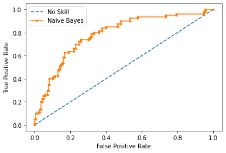

```python
dataset = Datos.Datos('ConjuntoDatos/german.data')
model = nb.GaussianNB()
trainX, testX, trainy, testy = ValidacionSimpleSK(dataset.datos, 0.75)
model.fit(trainX.astype(np.float), trainy.astype(np.float))

ns_probs = [0 for _ in range(len(testy))]
# predict probabilities
lr_probs = model.predict_proba(testX.astype(np.float))
# keep probabilities for the positive outcome only
lr_probs = lr_probs[:, 1]
# calculate scores
arraygood = []
for num in testy:
    arraygood.append(int(num) - 1)

ns_auc = roc_auc_score(testy, ns_probs)
lr_auc = roc_auc_score(testy, lr_probs)
print('No Skill: ROC AUC=%.3f' % (ns_auc))
print('Naive Bayes: ROC AUC=%.3f' % (lr_auc))
ns_fpr, ns_tpr, _ = roc_curve(arraygood, ns_probs)
lr_fpr, lr_tpr, _ = roc_curve(arraygood, lr_probs)
pyplot.plot(ns_fpr, ns_tpr, linestyle='--', label='No Skill')
pyplot.plot(lr_fpr, lr_tpr, marker='.', label='Naive Bayes')
pyplot.xlabel('False Positive Rate')
pyplot.ylabel('True Positive Rate')
pyplot.legend()
pyplot.show()
```

### Clasificador NB en el espacio ROC para tic-tac-toe

```
No Skill: ROC AUC=0.500
Naive Bayes: ROC AUC=0.617
```

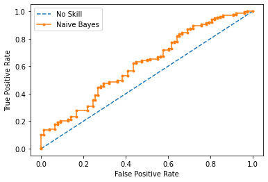

```python
dataset = Datos.Datos('ConjuntoDatos/tic-tac-toe.data')
model = nb.MultinomialNB(alpha=1.0, fit_prior=True, class_prior=None)
trainX, testX, trainy, testy = ValidacionSimpleSK(dataset.datos, 0.75)
model.fit(trainX.astype(np.float), trainy.astype(np.float))

ns_probs = [0 for _ in range(len(testy))]
lr_probs = model.predict_proba(testX.astype(np.float))
lr_probs = lr_probs[:, 1]

ns_auc = roc_auc_score(testy, ns_probs)
lr_auc = roc_auc_score(testy, lr_probs)
print('No Skill: ROC AUC=%.3f' % (ns_auc))
print('Naive Bayes: ROC AUC=%.3f' % (lr_auc))
ns_fpr, ns_tpr, _ = roc_curve(testy.astype(np.float), ns_probs)
lr_fpr, lr_tpr, _ = roc_curve(testy.astype(np.float), lr_probs)
pyplot.plot(ns_fpr, ns_tpr, linestyle='--', label='No Skill')
pyplot.plot(lr_fpr, lr_tpr, marker='.', label='Naive Bayes')
pyplot.xlabel('False Positive Rate')
pyplot.ylabel('True Positive Rate')
pyplot.legend()
pyplot.show()
```

Usando la AUC, obtenemos resultados similares que usando las medias de errores, es decir la probabilidad de acertar la clase de un ejemplo resulta mejor con el archivo german que con el tictactoe al estar usando validacion simple, lo que causaba problemas sobre el tictactoe mencionados anteriormente.